# Madison Weather

Jessi Kehe

This R Markdown document was adapted from documents created by Professor Bret Lager.

# Lecture: preparing data

We will be working with data set containing weather data on Madison collect over a number of years from different weather stations. In addition to investigating different scientific questions on the data, we will also be learning about the [`dplyr` package](https://dplyr.tidyverse.org/) from `tidyverse` which is “a grammar of data manipulation.”

### Import and Transform Data

Some details about loading our data:

- The data file has one row for each date and weather station
- The following block of code will read in the data, specifying the type of each variable
  - This step is necessary for this particular data set because `read_csv()` tries to guess the variable type from the first 1000 rows and some of these variables have missing data for all of the first 1000 rows; these get set to logical, which is wrong.

We will practice more with reading data later in the semester (for example, from Excel files, text files, URLs, and so one).

```r
## Read in the data
## Specify the type
# mw = read_csv("madison-weather-2020.csv")
mw = read_csv("madison-weather-2020.csv",
              col_types = cols(
  STATION = col_character(),
  NAME = col_character(),
  LATITUDE = col_double(),
  LONGITUDE = col_double(),
  ELEVATION = col_double(),
  DATE = col_date(format = ""),
  AWND = col_double(),
  PRCP = col_double(),
  SNOW = col_double(),
  SNWD = col_double(),
  TAVG = col_double(),
  TMAX = col_double(),
  TMIN = col_double(),
  WSF1 = col_double()
))

## Keep an original copy for below
mw_original = mw
```

### Examine Variables

```r
## Show the dimensions
dim(mw)
```

```
## [1] 102654     14
```

```r
## View the data; same as clicking on it in the Environment tab (upper right window)
#View(mw)
```

- There are over 100,000 observations
- There are 14 variables
- The Names in the `NAME` variable are not easy to work with

### Mutating Columns

#### Example using recode()

In R, valid names only use numbers, letters, and the underscore `_` and period `.` characters.

- Names are case-sensitive, so `a` and `A` are different.
- Names cannot begin with a number.

```r
## See what the complete list of names are:
mw %>% # take this data frame and then
  select(NAME) %>% # grab the NAME variable and then
  distinct()# show unique values
```

```
## # A tibble: 5 x 1
##   NAME
##   <chr>
## 1 UW ARBORETUM MADISON, WI US
## 2 MADISON DANE CO REGIONAL AIRPORT, WI US
## 3 CHARMANY FARM, WI US
## 4 MADISON WEATHER BUREAU CITY, WI US
## 5 MADISON MUNICIPAL AIRPORT, WI US
```

```r
## ------------------ an aside on the value of the pipe %>% -----------
## non-pipe equivalent number 1
temp1 = select(mw,NAME)
temp2 = distinct(temp1)
temp2
```

```
## # A tibble: 5 x 1
##   NAME
##   <chr>
## 1 UW ARBORETUM MADISON, WI US
## 2 MADISON DANE CO REGIONAL AIRPORT, WI US
## 3 CHARMANY FARM, WI US
## 4 MADISON WEATHER BUREAU CITY, WI US
## 5 MADISON MUNICIPAL AIRPORT, WI US
```

```r
rm(temp1,temp2)

## non-pipe equivalent number 2
## - read from the inside out
## - not too bad with only two functions
## - really hard to read with more complicated sets of instructions
distinct(select(mw,NAME))
```

```
## # A tibble: 5 x 1
##   NAME
##   <chr>
## 1 UW ARBORETUM MADISON, WI US
## 2 MADISON DANE CO REGIONAL AIRPORT, WI US
## 3 CHARMANY FARM, WI US
## 4 MADISON WEATHER BUREAU CITY, WI US
## 5 MADISON MUNICIPAL AIRPORT, WI US
```

```r
## --------------------------------------------------------------------
```

```r
## recode the NAME variable
## notice that names that do not follow the rules need to be bracketed with back ticks

## mutate() syntax:
##   mutate(.data, variable-name = value)
## usually called from a pipe, so we do not specify the data frame .data
##
## if variable-name exists, replaces the value with new value
## if the variable-name is not in the data frame, then create a new variable

## recode() syntax: use inside of mutate() or transmute()
## recode(variable-name, old-value-1 = "new-value-1", old-value-2 = "new-value-2", ...)
## See help (?recode) for more examples for other types of variables

## Notice that the old names do not have quotes
##   - they might have back ticks
## But the new names do have quotes
## Generally speaking, in tidyverse functions, you do not need quotes around names of variables in the data frame on which action is taking, but names not in this data frame need quotes
mw <- mw %>%
  mutate(NAME = recode(NAME,
                       `UW ARBORETUM MADISON, WI US` = "Arboretum",
                       `CHARMANY FARM, WI US` = "Charmany",
                       `MADISON DANE CO REGIONAL AIRPORT, WI US` = "Airport",
                       `MADISON WEATHER BUREAU CITY, WI US` = "Bureau",
                       `MADISON MUNICIPAL AIRPORT, WI US`= "Municipal_Airport"))
```

#### Example using select() and rename()

- The dplyr function `select()` will select variables from a data frame.
- The dplyr function `rename()` changes the name.

```r
## Select a few columns.
## Rename the variables with lower case letters
mw = mw %>%
  select(NAME,DATE,PRCP,SNOW,TMAX,TMIN) %>%
  rename(name = NAME,
         date = DATE,
         prcp = PRCP,
         snow = SNOW,
         tmax = TMAX,
         tmin = TMIN)
```

#### Other select() Examples

```r
## names() is a base R function to get/set the names of an object
## on a data frame, it returns the names of the variables
## These examples are meant to work with the original data set.
## Use mw_original which was created above after reading in the data

mw_original %>%
  names()
```

```
##  [1] "STATION"   "NAME"      "LATITUDE"  "LONGITUDE" "ELEVATION" "DATE"
##  [7] "AWND"      "PRCP"      "SNOW"      "SNWD"      "TAVG"      "TMAX"
## [13] "TMIN"      "WSF1"
```

```r
## minus
mw_original %>%
  select(-STATION) %>%
  names()
```

```
##  [1] "NAME"      "LATITUDE"  "LONGITUDE" "ELEVATION" "DATE"      "AWND"
##  [7] "PRCP"      "SNOW"      "SNWD"      "TAVG"      "TMAX"      "TMIN"
## [13] "WSF1"
```

```r
## partial reorder using everything()
mw_original %>%
  select(STATION,TMAX,TAVG,TMIN,everything()) %>%
  names()
```

```
##  [1] "STATION"   "TMAX"      "TAVG"      "TMIN"      "NAME"      "LATITUDE"
##  [7] "LONGITUDE" "ELEVATION" "DATE"      "AWND"      "PRCP"      "SNOW"
## [13] "SNWD"      "WSF1"
```

```r
## examples with starts_with(), ends_with(), and contains()
mw_original %>%
  select(NAME,starts_with("T")) %>%
  names()
```

```
## [1] "NAME" "TAVG" "TMAX" "TMIN"
```

```r
mw_original %>%
  select(ends_with("E")) %>%
  names()
```

```
## [1] "NAME"      "LATITUDE"  "LONGITUDE" "DATE"
```

```r
mw_original %>%
  select(contains("AT")) %>%
  names()
```

```
## [1] "STATION"   "LATITUDE"  "ELEVATION" "DATE"
```

# Lecture: filter() and summarize()

#### Eliminate weather stations with many missing observations

```r
## Find earliest and latest date
## Find number of dates in range
## Find number of missing observations in range

mw %>%
  group_by(name) %>%
  summarize(min = min(date), # earliest date by name
            max = max(date), # most recent date by name
            n = max - min + 1, # total number of days at named station
            na = sum(date >= min & date <= max & is.na(tmax))) # number of days at the named station with no tmax measurements
```

[output not shown]

```r
## Decide to use all Airport data and only use Bureau data through 1939-09-30
## vertical bar `|` mean elementwise `OR'
## Note use of double equal signs == to check equality
#--> This is different from a single equal sign = used for assignment or labeling function arguments
## Keep rows where name is "Airport" or where the date is prior to October 1, 1939
## All of the early dates are at "Bureau"

mw = mw %>%
  filter(name == "Airport" | (name == "Bureau" & date < "1939-10-01") )

## Double check
mw %>%
  group_by(name) %>%
  summarize(min = min(date),max=max(date))
```

```
## # A tibble: 2 x 3
##   name    min        max
##   <chr>   <date>     <date>
## 1 Airport 1939-10-01 2020-08-28
## 2 Bureau  1869-01-01 1939-09-30
```

```r
## Check missing data
## Here is an example of defining a function in place
## and passing it as an argument to another function
mw %>%
  summarize_all(function(x) sum(is.na(x)))
```

```
## # A tibble: 1 x 6
##    name  date  prcp  snow  tmax  tmin
##   <int> <int> <int> <int> <int> <int>
## 1     0     0    11  5516     4     5
```

```r
## Here is an alternative:
## define and create a function (see R4DS Chapter 19)
## Pass it to the summarize_all()
count_na = function(x)
{
  return( sum(is.na(x)) )
}

mw %>%
  summarize_all(count_na)
```

```
## # A tibble: 1 x 6
##    name  date  prcp  snow  tmax  tmin
##   <int> <int> <int> <int> <int> <int>
## 1     0     0    11  5516     4     5
```

```r
## To study temperature, drop snow and then drop missing data
## Later, we can add snow back in if we want to examine snowfall.
mw <- mw %>%
  select(-snow) %>%
  drop_na()
str(mw)
```

```
## tibble [55,366 × 5] (S3: tbl_df/tbl/data.frame)
##  $ name: chr [1:55366] "Airport" "Airport" "Airport" "Airport" ...
##  $ date: Date[1:55366], format: "1939-10-01" "1939-10-02" ...
##  $ prcp: num [1:55366] 0 0 0 0 0 0 0 0.06 0.38 0 ...
##  $ tmax: num [1:55366] 67 70 74 81 70 77 85 79 75 67 ...
##  $ tmin: num [1:55366] 33 38 48 51 56 45 47 59 58 44 ...
```

#### Summarize Examples

```r
## Calculate average temperature and total precipitation by year
## Drop partial year of 2020
## Add a period for 30-year periods from 1869 through 2019
breaks = seq(1869,2019,30)
labels = str_c((breaks+1)[-6],breaks[-1],sep="-")
mw_year = mw %>%
  mutate(tavg = (tmin+tmax)/2) %>%
  mutate(year = year(date)) %>%
  filter(year < 2020 & year > 1869) %>%
  group_by(year) %>%
  summarize(n = n(),
            tmin = mean(tmin),
            tavg = mean(tavg),
            tmax = mean(tmax),
            prcp = sum(prcp)) %>%
  mutate(period = cut(year,
                      breaks = breaks,
                      labels = labels))
str(mw_year)
```

```
## tibble [150 × 7] (S3: tbl_df/tbl/data.frame)
##  $ year  : num [1:150] 1870 1871 1872 1873 1874 ...
##  $ n     : int [1:150] 365 365 366 365 365 365 366 365 365 365 ...
##  $ tmin  : num [1:150] 41.7 40.1 37.6 38 40.2 ...
##  $ tavg  : num [1:150] 47.8 46.3 44 44 46.5 ...
##  $ tmax  : num [1:150] 53.9 52.4 50.4 50.1 52.7 ...
##  $ prcp  : num [1:150] 28.1 29.4 22.4 27.6 29.1 ...
##  $ period: Factor w/ 5 levels "1870-1899","1900-1929",..: 1 1 1 1 1 1 1 1 1 1 ...
```

```r
## Summarize by month and period
mw_month = mw %>%
  mutate(tavg = (tmin+tmax)/2) %>%
  mutate(month = month(date, label=TRUE)) %>%
  mutate(year = year(date)) %>%
  filter(year < 2020 & year > 1869) %>%
  mutate(period = cut(year,
                      breaks = breaks,
                      labels = labels)) %>%
  group_by(period,month) %>%
  summarize(n=n(),
            tmin = mean(tmin),
            tmax = mean(tmax),
            tavg = mean(tavg),
            prcp = sum(prcp))
mw_month
```

```
## # A tibble: 60 x 7
## # Groups:   period [5]
##    period    month     n  tmin  tmax  tavg  prcp
##    <fct>     <ord> <int> <dbl> <dbl> <dbl> <dbl>
##  1 1870-1899 Jan     930  8.60  23.4  16.0  53.9
##  2 1870-1899 Feb     847 12.2   27.5  19.9  47.3
##  3 1870-1899 Mar     930 22.3   36.3  29.3  67.2
##  4 1870-1899 Apr     900 37.8   54.0  45.9  74.1
##  5 1870-1899 May     930 50.0   66.7  58.4 104.
##  6 1870-1899 Jun     900 60.1   76.5  68.3 129.
##  7 1870-1899 Jul     930 64.7   80.9  72.8 116.
##  8 1870-1899 Aug     930 62.5   78.4  70.4  90.6
##  9 1870-1899 Sep     900 54.2   70.1  62.1  96.1
## 10 1870-1899 Oct     930 41.9   57.0  49.5  73.7
## # … with 50 more rows
```

## Daily average temperature by period, month, and day

Calculate and graph the daily average temperature by period, month, and day. Graph with lines using different colors for each period.

Does it look like the average temperature is increasing over time?

```r
mw_day <- mw %>%
  mutate(tavg = (tmin+tmax)/2) %>%
  mutate(year = year(date)) %>%
  mutate(month = month(date, label=TRUE)) %>%
  mutate(day = day(date)) %>%
  filter(year < 2020 & year > 1869) %>%
  mutate(period = cut(year,
                      breaks = breaks,
                      labels = labels)) %>%
  group_by(period,month,day) %>%
  summarize(n=n(),tavg = mean(tavg))
mw_day
```

```
## # A tibble: 1,830 x 5
## # Groups:   period, month [60]
##    period    month   day     n  tavg
##    <fct>     <ord> <int> <int> <dbl>
##  1 1870-1899 Jan       1    30  19.9
##  2 1870-1899 Jan       2    30  17.5
##  3 1870-1899 Jan       3    30  15.2
##  4 1870-1899 Jan       4    30  15
##  5 1870-1899 Jan       5    30  16.6
##  6 1870-1899 Jan       6    30  15.9
##  7 1870-1899 Jan       7    30  14.7
##  8 1870-1899 Jan       8    30  14.9
##  9 1870-1899 Jan       9    30  14.9
## 10 1870-1899 Jan      10    30  15.3
## # … with 1,820 more rows
```

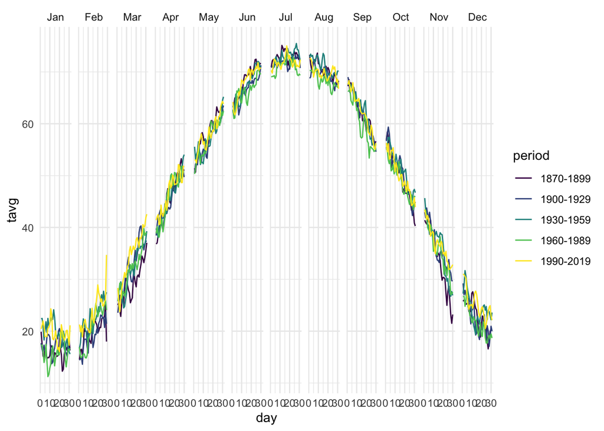

```r
ggplot(mw_day, aes(x=day,y=tavg,color=period)) +
  geom_line() +
  facet_grid(~month)
```

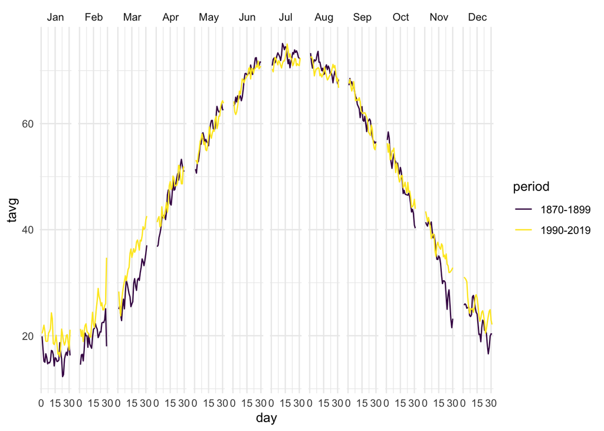

```r
mw_day %>%
  filter(period == "1870-1899" | period == "1990-2019") %>%
  ggplot(aes(x=day,y=tavg,color=period)) +
  geom_line() +
  facet_grid(~month) +
  scale_x_continuous(limits = c(0, 31),
      breaks = c(0, 15, 30))
```

# Lecture: Temperature Questions

The previous plots raise some questions.

### 1

> What is the average daily maximum/average/minimum temperature by period and month?

```r
## preliminary calculations to add variables to the daily data
## Much of this code was copied from above
## Create a second data frame mw2 which adds columns for tavg, year, month, day, and period
## and eliminates the partial 2020 year.

mw2 <- mw %>%
  mutate(tavg = (tmin+tmax)/2) %>%
  mutate(year = year(date)) %>%
  mutate(month = month(date, label=TRUE)) %>%
  mutate(day = day(date)) %>%
  filter(year < 2020 & year > 1869) %>%
  mutate(period = cut(year,
                      breaks = breaks,
                      labels = labels)) %>%
  arrange(date)

## answer the question
mw2 %>%
  group_by(month,period) %>%
  summarize(tmax = mean(tmax),
            tavg = mean(tavg),
            tmin = mean(tmin)) #%>%
```

```
## # A tibble: 60 x 5
## # Groups:   month [12]
##    month period     tmax  tavg  tmin
##    <ord> <fct>     <dbl> <dbl> <dbl>
##  1 Jan   1870-1899  23.4  16.0  8.60
##  2 Jan   1900-1929  25.0  17.3  9.53
##  3 Jan   1930-1959  27.9  19.8 11.6
##  4 Jan   1960-1989  24.5  15.8  7.03
##  5 Jan   1990-2019  27.5  19.6 11.7
##  6 Feb   1870-1899  27.5  19.9 12.2
##  7 Feb   1900-1929  26.8  19.1 11.4
##  8 Feb   1930-1959  30.8  22.4 14.0
##  9 Feb   1960-1989  29.9  20.4 11.0
## 10 Feb   1990-2019  31.6  23.3 14.9
## # … with 50 more rows
```

```r
  #pivot_wider(names_from=period,values_from=tmax) ## This is a preview of an upcoming topic to reshape data
```

### 2

> What is the slope of a regression line by average temperature by period and month? Which months have the steepest increases and decreases?

```r
get_slope = function(x,y)
{
  fit = lm(y ~ x)
  return( (coef(fit))[2] )
}

mw2 %>%
  group_by(month,period) %>%
  summarize(slope = get_slope(day,tavg)) %>%
  pivot_wider(names_from=period,values_from=slope) #%>% ## Preview of a tidyr command
```

```
## # A tibble: 12 x 6
## # Groups:   month [12]
##    month `1870-1899` `1900-1929` `1930-1959` `1960-1989` `1990-2019`
##    <ord>       <dbl>       <dbl>       <dbl>       <dbl>       <dbl>
##  1 Jan      -0.00487    -0.00681      -0.188      0.0674     -0.0710
##  2 Feb       0.247       0.301         0.308      0.449       0.289
##  3 Mar       0.357       0.474         0.427      0.415       0.525
##  4 Apr       0.515       0.393         0.465      0.485       0.384
##  5 May       0.373       0.376         0.337      0.364       0.332
##  6 Jun       0.315       0.283         0.323      0.230       0.305
##  7 Jul       0.0179      0.0494        0.106      0.0309      0.0221
##  8 Aug      -0.141      -0.107        -0.144     -0.117      -0.0795
##  9 Sep      -0.410      -0.430        -0.443     -0.454      -0.432
## 10 Oct      -0.507      -0.478        -0.384     -0.337      -0.395
## 11 Nov      -0.704      -0.456        -0.568     -0.490      -0.362
## 12 Dec      -0.270      -0.295        -0.180     -0.282      -0.228
```

```r
  # ungroup() %>%
  # mutate(month_mean = round(rowMeans(select(.,c(2,3))),2))
```

> The months with the largest warming trends from beginning to end are March and April

> The months with the largest cooling trends are September through November

### 3

> Has there been a change in extreme temperature events over time? Compare maximum and minimum temperatures for the month by period and month.

```r
mw_day_extreme <- mw %>%
  mutate(year = year(date)) %>%
  mutate(month = month(date, label=TRUE)) %>%
  mutate(day = day(date)) %>%
  filter(year < 2020 & year > 1869) %>%
  mutate(period = cut(year,
                      breaks = breaks,
                      labels = labels)) %>%
  group_by(period,month,day) %>%
  summarize(n=n(), tmax = mean(tmax), tmin = mean(tmin))
```

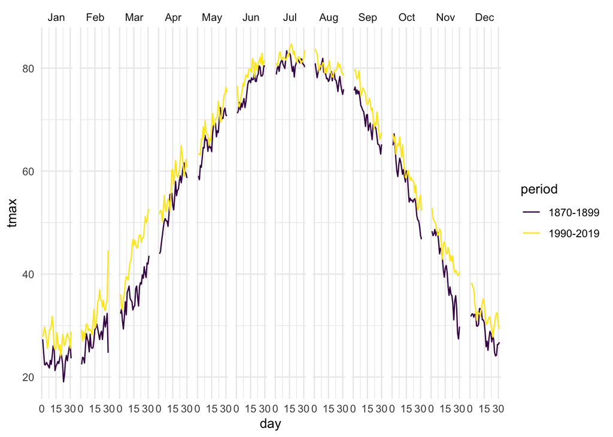

```r
mw_day_extreme %>%
  filter(period == "1870-1899" | period == "1990-2019") %>%
  ggplot(aes(x=day,y=tmax,color=period)) +
    geom_line() +
    facet_grid(~month) +
    scale_x_continuous(limits = c(0, 31),
      breaks = c(0, 15, 30))
```

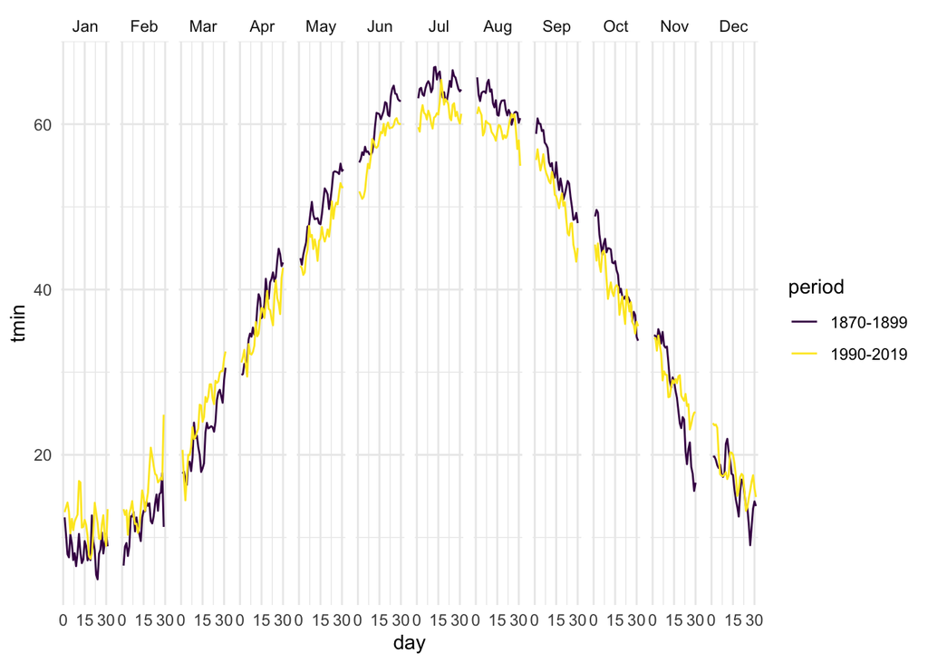

```r
mw_day_extreme %>%
  filter(period == "1870-1899" | period == "1990-2019") %>%
  ggplot(aes(x=day,y=tmin,color=period)) +
    geom_line() +
    facet_grid(~month) +
    scale_x_continuous(limits = c(0, 31),
      breaks = c(0, 15, 30))
```

# Lecture: Precipitation Questions

### 4

> Create a table named mw_pr_1 that has one row per month and day (so 366 rows) with columns named for month, day, pmax (maximum precipitation), and pmin (minimum precipitation).

```r
mw_pr_4 = mw2 %>%
  select(date,period,year,month,day,prcp) %>%
  drop_na() %>%
  group_by(month,day) %>%
  summarize(n=n(),pmax = max(prcp),pmin = min(prcp))
```

### 5

> Create a plot with a line segment from pmin to pmax for each day of the year. Use geom_segment() to add the lines and use a facet command (either facet_wrap() or facet_grid()) to draw the lines for each month in a different panel.

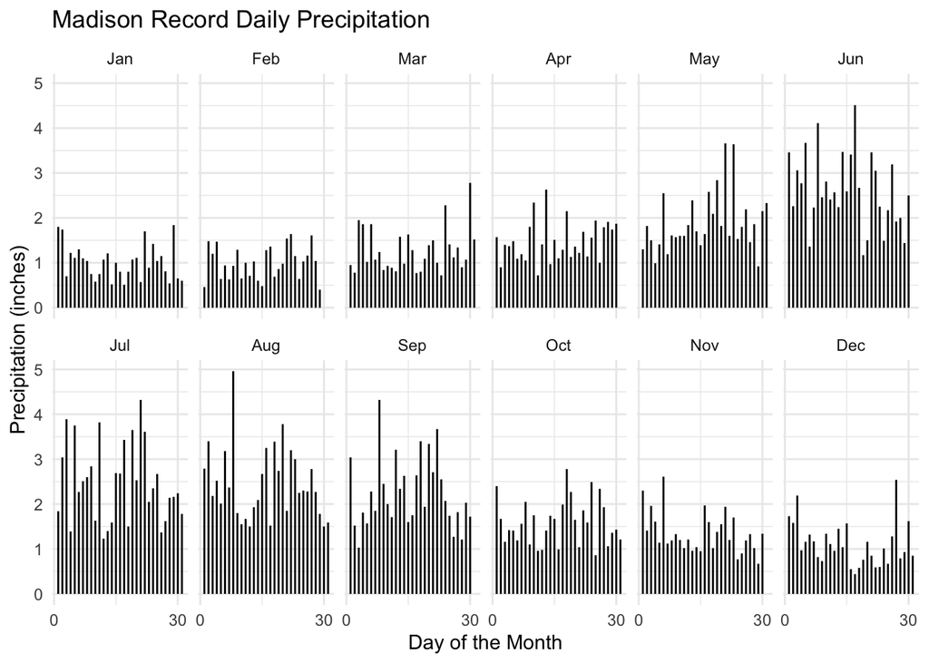

```r
ggplot(mw_pr_4) +
  geom_segment(aes(x=day,xend=day,y=pmin,yend=pmax)) +
  facet_wrap(~month,nrow=2) +
  #facet_grid(.~month) + #rows ~ columns
  xlab("Day of the Month") +
  ylab("Precipitation (inches)") +
  ggtitle("Madison Record Daily Precipitation") +
  scale_x_continuous(breaks = c(0,30))
```

### 6

> Filter the Madison weather data set to keep only days that achieve the record high precipitation for that day (including ties) and select the period, year, month, day, and pmax variables.

```r
mw_pr_6 = mw2 %>%
  select(date,period,year,month,day,prcp) %>%
  drop_na() %>%
  group_by(month,day) %>%
  slice_max(prcp, n=1) %>% #?slice_max()
  arrange(month,day)
mw_pr_6
```

```
## # A tibble: 369 x 6
## # Groups:   month, day [366]
##    date       period     year month   day  prcp
##    <date>     <fct>     <dbl> <ord> <int> <dbl>
##  1 1892-01-01 1870-1899  1892 Jan       1 1.8
##  2 1876-01-02 1870-1899  1876 Jan       2 1.74
##  3 1906-01-03 1900-1929  1906 Jan       3 0.7
##  4 1874-01-04 1870-1899  1874 Jan       4 1.22
##  5 1939-01-05 1930-1959  1939 Jan       5 1.11
##  6 1885-01-06 1870-1899  1885 Jan       6 1.3
##  7 2019-01-07 1990-2019  2019 Jan       7 1.1
##  8 1937-01-08 1930-1959  1937 Jan       8 1.04
##  9 1889-01-09 1870-1899  1889 Jan       9 0.75
## 10 2017-01-10 1990-2019  2017 Jan      10 0.580
## # … with 359 more rows
```

### 7

> Use the data from the previous problem. Count for every year the number of record high precipitation events that occur. Plot these counts by year and add a trend line/curve. Does it appear that the rate of record high precipitation days is increasing?

```r
mw_pr_7 = mw_pr_6 %>%
  group_by(period,year) %>%
  summarize(n=n())
mw_pr_7
```

```
## # A tibble: 133 x 3
## # Groups:   period [5]
##    period     year     n
##    <fct>     <dbl> <int>
##  1 1870-1899  1870     2
##  2 1870-1899  1871     5
##  3 1870-1899  1872     1
##  4 1870-1899  1873     1
##  5 1870-1899  1874     3
##  6 1870-1899  1875     2
##  7 1870-1899  1876     6
##  8 1870-1899  1877     2
##  9 1870-1899  1878     3
## 10 1870-1899  1879     6
## # … with 123 more rows
```

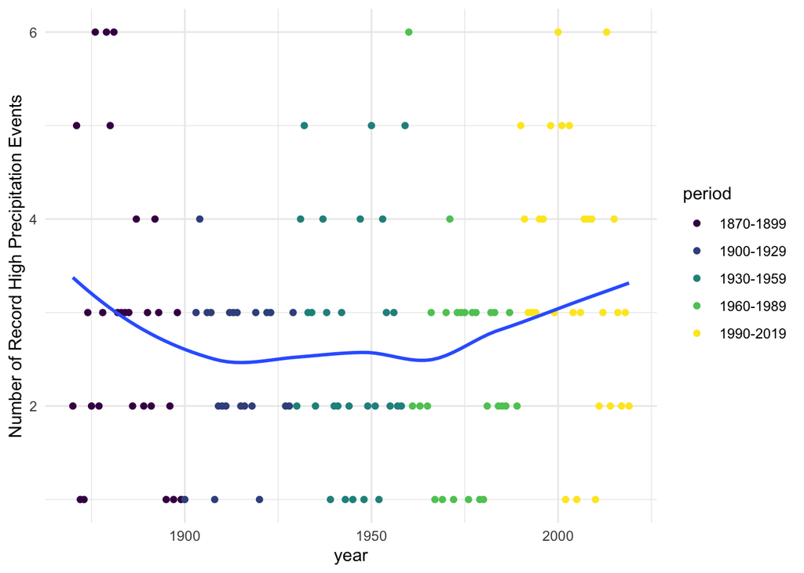

```r
ggplot(mw_pr_7, aes(x=year,y=n)) +
  geom_point(aes(color=period)) +
  geom_smooth(se=FALSE) +
  ylab("Number of Record High Precipitation Events")
```

### 8

> Among all days with precipitation greater than zero, find the cutoff value for the top one percent. Count the number of these top one percent precipitation days by period. Is there a trend of more extreme precipitation events in more recent years?

```r
topone <- mw %>%
  select(prcp) %>%
  drop_na() %>%
  filter(prcp > 0) %>%
  summarize(q99 = quantile(prcp,prob=0.99))
topone
```

```
## # A tibble: 1 x 1
##     q99
##   <dbl>
## 1  1.93
```

```r
mw_pextreme <- mw2 %>%
  select(period,date,year,month,day,prcp) %>%
  drop_na() %>%
  filter(prcp >= topone$q99) %>%
  group_by(period) %>%
  summarize(n=n())
mw_pextreme
```

```
## # A tibble: 5 x 2
##   period        n
##   <fct>     <int>
## 1 1870-1899    32
## 2 1900-1929    25
## 3 1930-1959    25
## 4 1960-1989    35
## 5 1990-2019    54
```

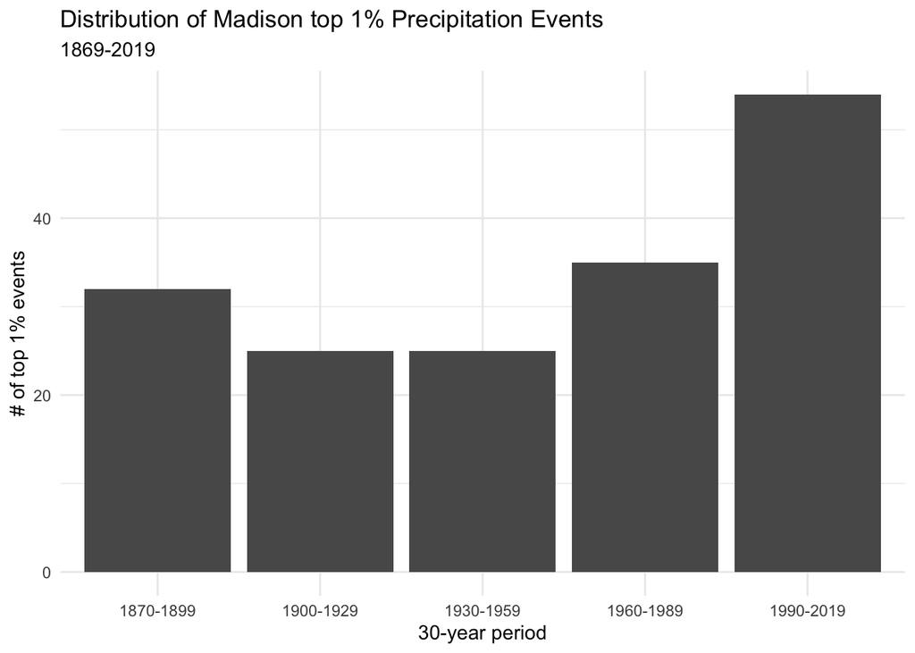

```r
ggplot(mw_pextreme, aes(x=period,y=n)) +
  geom_col() +
  xlab("30-year period") +
  ylab("# of top 1% events") +
  ggtitle("Distribution of Madison top 1% Precipitation Events",
          subtitle="1869-2019")
```